# Exercise 5

Pol Puig

7/20/2020

First of all, we need to load the dataset:

```r
library(foreign)
data <- read.spss("http://84.89.132.1/~satorra/R2014/properties.sav", to.data.frame=TRUE)
```

```
## re-encoding from CP1252
```

```r
head(data)
```

```
##   sold    price rural pool surface         habSize region
## 1    0 239443.2    No   No  189.20 (10000,50000]       01
## 2    1 192000.0    No   No  149.22 (50000,1000000]     05
## 3    1 200000.0    No  Yes  149.00 (50000,1000000]     19
## 4    0 191763.0    No   No  112.63 (10000,50000]       06
## 5    0 242500.0    No   No  103.25 (10000,50000]       06
## 6    0 263500.0    No  Yes  126.00 (0,10000]           01
```

### 1.- Do the variable price requires transformation? Comment

Firstly, let’s scatterplot price on surface to see what relation they potentally have:

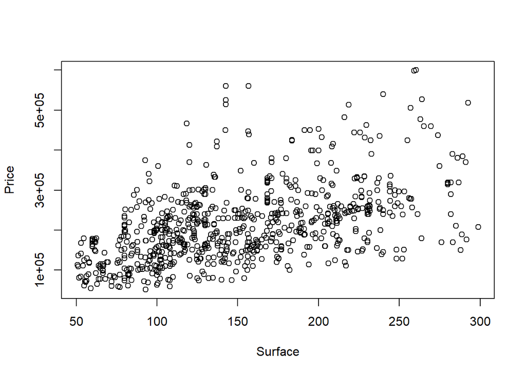

```r
plot( data$surface, data$price, xlab="Surface", ylab="Price")
```

We notice that there is a lot of dispersion of price the higher the house surface is. We will try to solve this by applying logarithms on the variable price:

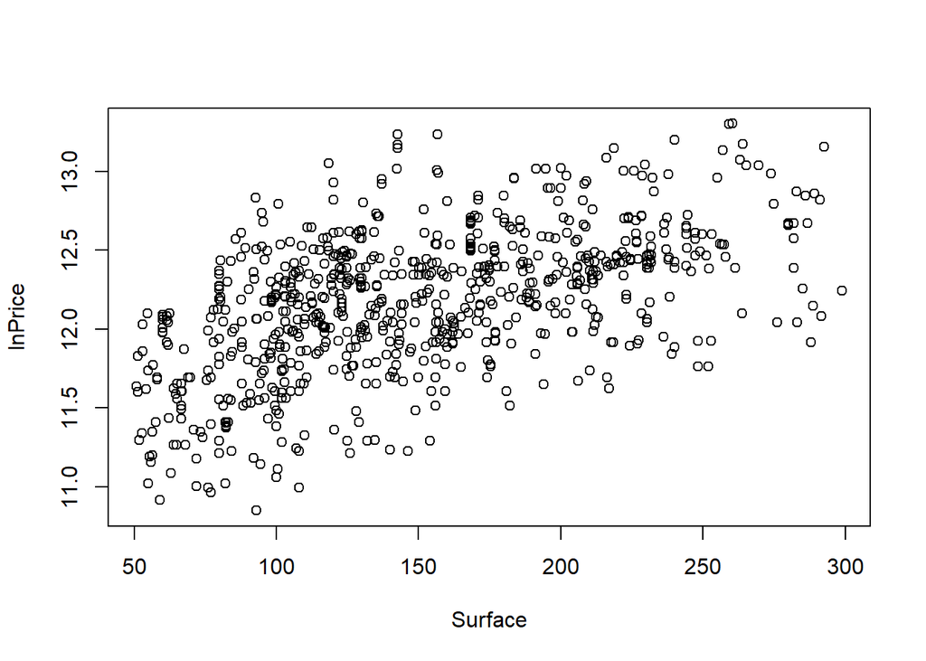

```r
data$lnprice = log(data$price)
plot(data$surface, data$lnprice,  xlab="Surface", ylab="lnPrice")
```

Looking at the graph, we can notice that the dispersion we had before changed to a more “regular” dispersion. So, we can conclude saying that the variable price requires a transformation: we compute the logarithm of this variable.

### 2.- Fit the linear regression of log(price) on the covariate surface

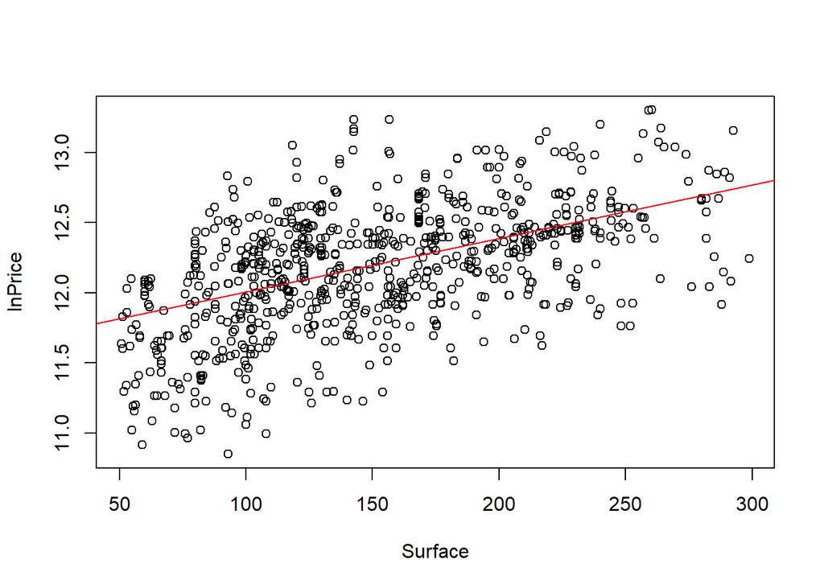

```r
plot(data$surface, data$lnprice,  xlab="Surface", ylab="lnPrice")
model1 <- lm(lnprice~surface, data=data)
abline(model1, col="red")
```

As we saw on the previous section, doing the log of price, makes a model that is somewhat more ajusted than not doing logs but we have still a lot of dispersion.

### 3.- The same regression but for each of the groups defined by sold. The same two group regression but now with the same slop. Comment the results. Find a set of reasonable covariates for log(price) . Do a post fit analysis based on residuals vs fitted y plot, partial-regression plots, information on collinearity of predictor (for that you can use avPlots in the car Report on the multiple regression and extract general conclusions.

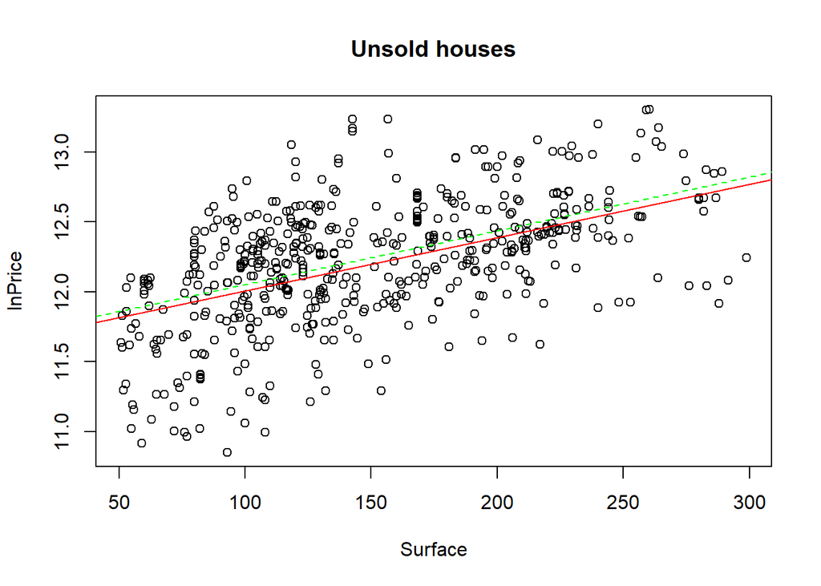

```r
plot(data$surface[data$sold == 0], data$lnprice[data$sold == 0],  xlab="Surface", ylab="lnPrice", main="Unsold houses")
model2 <- lm(lnprice[sold == 0]~surface[sold == 0], data=data)
abline(model2, col="green", lty=2)
abline(model1, col="red")
```

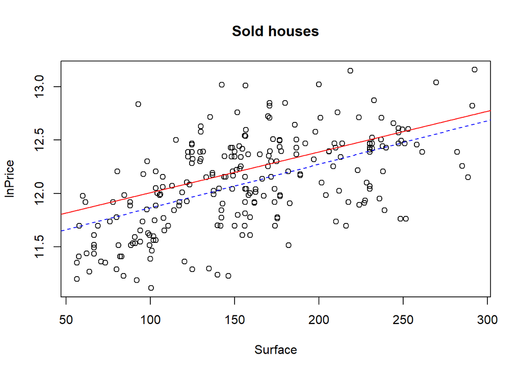

```r
plot(data$surface[data$sold == 1], data$lnprice[data$sold == 1],  xlab="Surface", ylab="lnPrice", main="Sold houses")
model2 <- lm(lnprice[sold == 1]~surface[sold == 1], data=data)
abline(model2, col="blue", lty=2)
abline(model1, col="red")
```

On red we have the regression line of the model without taking into account the sold variable. The green and blue regression lines are the regression lines of the model by splitting the variable sold. As we can see, the regression of not sold houses is quite similar to the regression of both groups together, the line is only a little bit shifted upwards. Looking at sold houses graph we see that is also a little bit shifted downwards but the slope is almost the same.

```r
library(car)
```

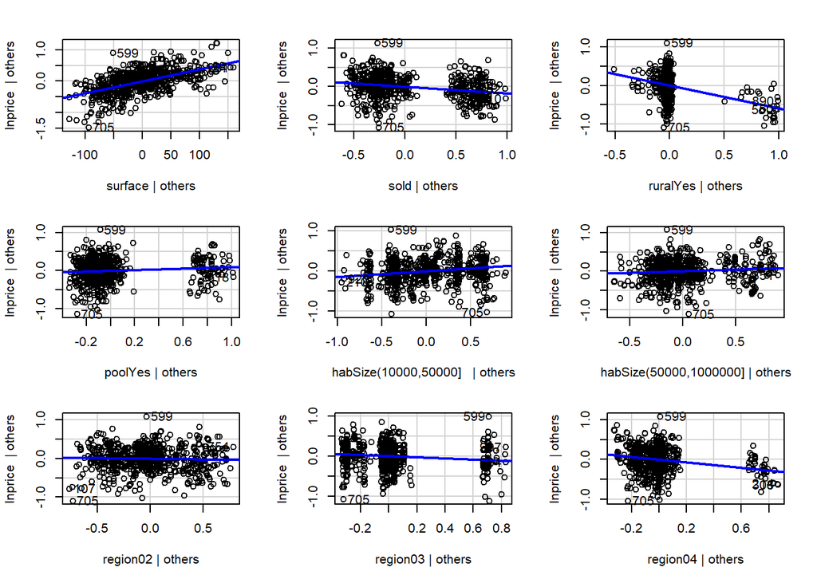

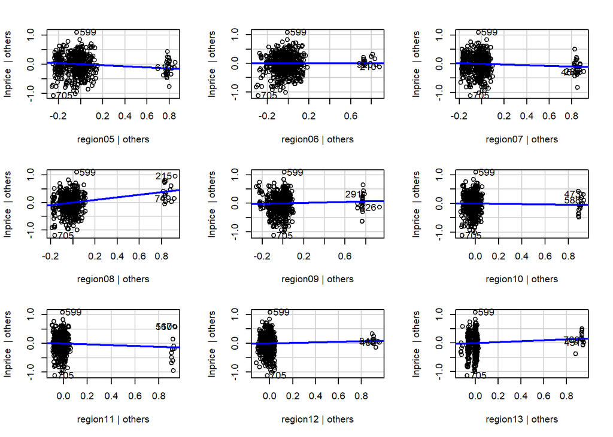

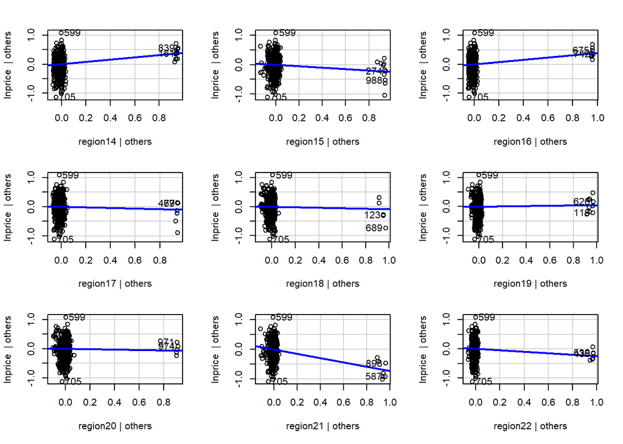

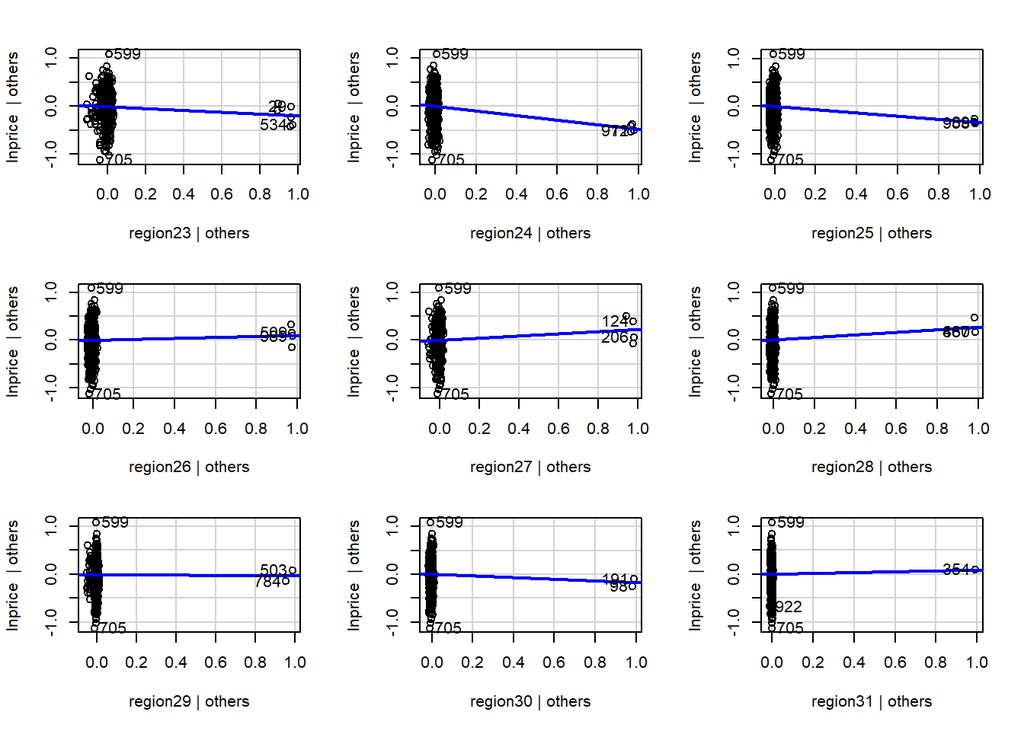

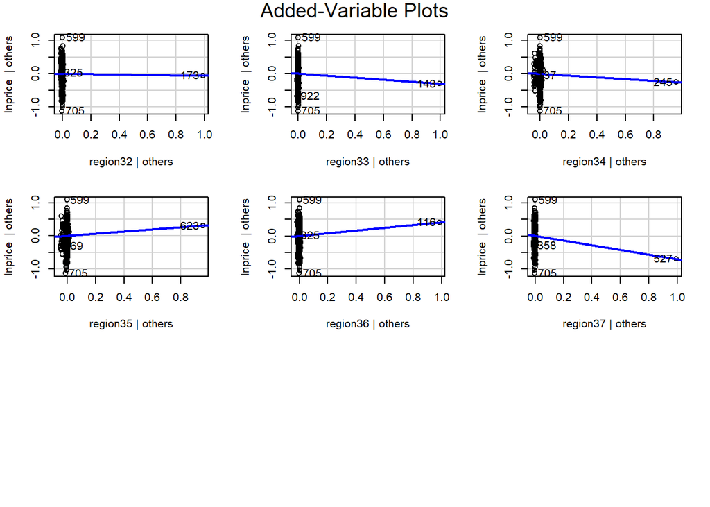

```r
model4 <- lm(lnprice ~ surface + sold + rural + pool + habSize + region, data=data)
avPlots(model4)
```

Now that we have this model, let’s see residuals vs fitted values:

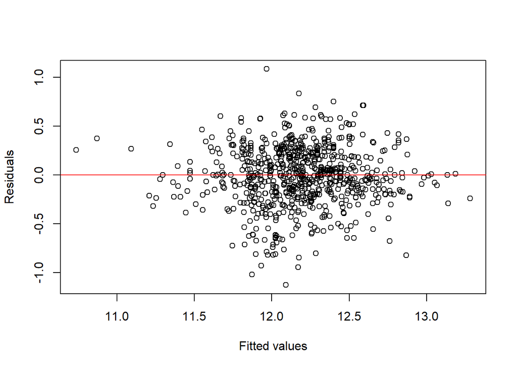

```r
plot(model4$fitted.values, model4$residuals, xlab="Fitted values", ylab="Residuals")
abline(h=0, col="red")
```

### 4.- Now you are ask to find a predicting model for house prices. Which of the two models would you favor?: log(price) or log(price/surface)

```r
summary(model4)$r.squared
```

```
## [1] 0.5612799
```

Now let’s compute the other model: log(price/surface)

```r
lnpricesurface = log(data$price / data$surface)
model5 <- lm(lnpricesurface ~ sold + rural + pool + habSize + region, data=data)
summary(model5)$r.squared
```

```
## [1] 0.3874421
```

As we can see, we get a lower r-squared doing the log(price/surface). So we prefer the first model(lnprice)

### 5.- Using your final model, predict the selling prices of the unsold properties.

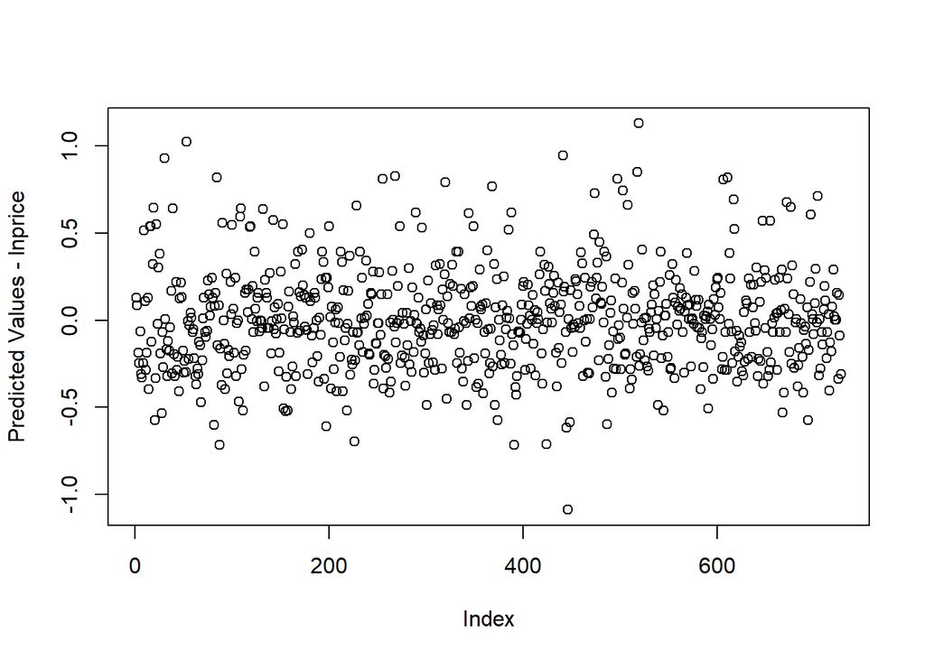

```r
data2 <- subset(data, sold == 0)
predictedValues <- predict(model4, data2)
plot(predictedValues-data2$lnprice, ylab="Predicted Values - lnprice")
```

As we can see, our predicted values are quite good. The difference between the predicted value and the logarithm of the price are quite close to 0 on average for unsold properties.